# Predicting tumor subgroup in single cells

Steven Foltz

2023

This notebook uses a medulloblastoma subgroup prediction model to predict the subgroup of individual cells from single-cell RNA-seq experiments. Models were trained using bulk gene expression data (bulk array and RNA-seq) in `analysis_notebooks/baseline_models.Rmd`. Here, we use the trained model to predict single cell subgroups from scRNA-seq data generated by [Hovestadt, et. al](https://www.nature.com/articles/s41586-019-1434-6).

# Setup

```r
# Load libraries
source(here::here("utils/color_schemes.R"))
source(here::here("utils/modeling.R"))
source(here::here("utils/single-cell.R"))
library(glmnet)
```

```r
# Input files

processed_data_dir <- here::here("processed_data")
models_dir <- here::here("models")
pseudobulk_sce_dir <- file.path(processed_data_dir, "pseudobulk_sce")

pseudobulk_metadata_filepath <- file.path(processed_data_dir, "pseudobulk_metadata.tsv")

gene_map_filepath <- file.path(processed_data_dir, "gene_map.tsv")

# baseline models are generated prior to this in the notebook analysis_notebooks/baseline_models.Rmd
# there is one baseline model designated as the official model that is used to test single cells here
# "baseline" means that we used all genes and all available training/test data in modeling
baseline_models_filepath <- file.path(models_dir, "baseline.rds")

# Output files
plots_dir <- here::here("plots")
percentage_subgroups_plot_filepath <- file.path(plots_dir, "single_cell_percentage_subgroups.pdf")
relative_confidence_plot_filepath <- file.path(plots_dir, "single_cell_relative_confidence.pdf")
combined_umap_plot_filepath <- file.path(plots_dir, "single_cell_combined_umap.pdf")

# Read in data
pseudobulk_metadata_df <- readr::read_tsv(pseudobulk_metadata_filepath,
                                          show_col_types = FALSE) |>
  dplyr::mutate(sample_accession = title) |>
  dplyr::mutate(platform = "RNA-seq")

gene_map_df <- readr::read_tsv(gene_map_filepath,
                               show_col_types = FALSE)

baseline_models <- readr::read_rds(baseline_models_filepath)
ktsp_classifier <- baseline_models[[1]]$ktsp$classifier #separate issue: pick the designated model
rf_classifier <- baseline_models[[1]]$rf$classifier
```

# Predict the subgroup of single cells

```r
test_object_list <- lapply(pseudobulk_metadata_df$title,
                           function(x) test_single_cells(sample_acc = x,
                                                         sce_filepath = file.path(pseudobulk_sce_dir, stringr::str_c(x, "_sce.rds")),
                                                         metadata_df = pseudobulk_metadata_df,
                                                         gene_map_df = gene_map_df,
                                                         labels = c("G3", "G4", "SHH", "WNT"),
                                                         classifier = ktsp_classifier,
                                                         model_type = "ktsp",
                                                         study = "GSE119926",
                                                         platform = "scRNA-seq")) |>
  purrr::set_names(pseudobulk_metadata_df$title)
```

# Plot single cell subgroup predictions

### Prep plotting data

```r
counts_subgroup_prediction_df <- purrr::map(test_object_list,
                                            function(x) x$predicted_labels_df |>
                                              tidyr::separate_wider_delim(cols = sample_accession,
                                                                          delim = "_",
                                                                          names = c("sample_accession", "index")) |>
                                              dplyr::count(sample_accession,
                                                           predicted_labels)) |>
  dplyr::bind_rows() |>
  dplyr::left_join(pseudobulk_metadata_df,
                   by = "sample_accession")
```

### Plot percentage of subgroups

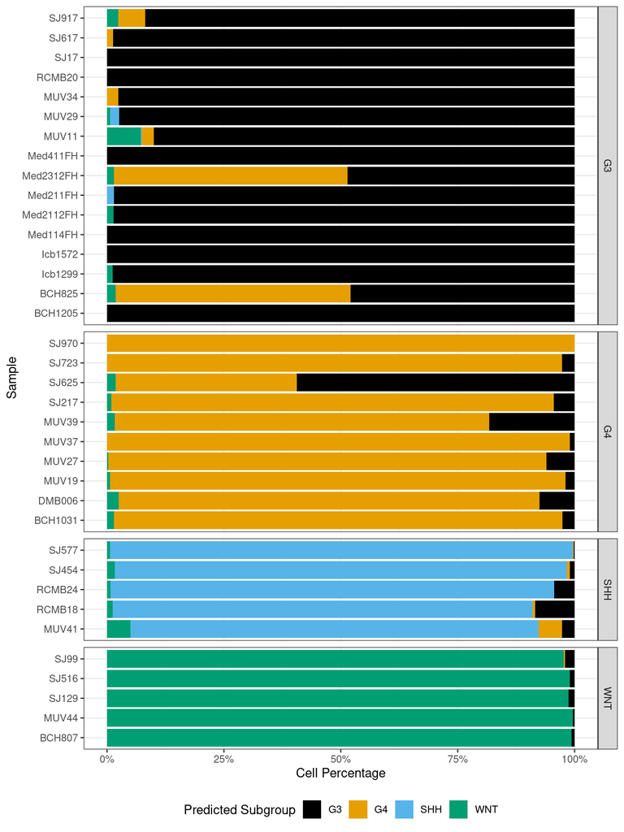

```r
percentage_subgroups_plot_object <- counts_subgroup_prediction_df |>
  ggplot2::ggplot(ggplot2::aes(y = sample_accession,
                               x = n,
                               fill = predicted_labels)) +
  ggplot2::geom_col(position = ggplot2::position_fill()) +
  ggplot2::scale_x_continuous(labels = scales::percent) +
  ggplot2::facet_grid(rows = ggplot2::vars(subgroup),
                      space = "free_y",
                      scales = "free_y") +
  ggplot2::scale_fill_manual(values = okabe_ito_colors) +
  ggplot2::labs(y = "Sample",
                x = "Cell Percentage",
                fill = "Predicted Subgroup") +
  ggplot2::theme_bw() +
  ggplot2::theme(legend.position = "bottom")

ggplot2::ggsave(filename = percentage_subgroups_plot_filepath,
                plot = percentage_subgroups_plot_object,
                height = 10,
                width = 7.5)

percentage_subgroups_plot_object
```

- Most samples show the same tumor subgroup predicted for most of their cells
- Three samples (“BCH825”, “Med2312FH”, “SJ625”) show a mixture of predicted subgroups (G3/G4)

# Plot confidence of subgroup predictions

### Prep plotting data

Three samples in particular are of interest given the mixture of subgroups predicted (“BCH825”, “Med2312FH”, “SJ625”). Four other samples can serve as representative samples from each subgroup (“BCH1205”, “BCH1031”, “MUV41”, “BCH807”).

```r
sample_titles <- sort(c("BCH825", "Med2312FH", "SJ625", "BCH1205", "BCH1031", "MUV41", "BCH807"))
sample_titles_with_subgroup <- pseudobulk_metadata_df |>
  dplyr::filter(title %in% sample_titles) |>
  dplyr::mutate(title_with_subgroup = stringr::str_c(title, " (", subgroup, ")")) |>
  dplyr::pull(title_with_subgroup) |>
  sort()

umap_labels_combined_df <- NULL
for(i in 1:length(sample_titles)) {

  sample_title <- sample_titles[i]
  sample_title_with_subgroup <- sample_titles_with_subgroup[i]

  sce_filepath <- file.path(pseudobulk_sce_dir, stringr::str_c(sample_title, "_sce.rds"))
  sce_object <- readr::read_rds(sce_filepath)
  umap_df <- data.frame(sample = sample_title,
                        sample_with_subgroup = sample_title_with_subgroup,
                        SingleCellExperiment::reducedDim(sce_object, "UMAP"),
                        cluster = SummarizedExperiment::colData(sce_object)$louvain_10)
  names(umap_df) <- c("sample", "sample_with_subgroup", "UMAP_1", "UMAP_2", "cluster")

  labels_df <- test_object_list[[sample_title]][["model_output"]] |>
    tibble::as_tibble() |>
    dplyr::rowwise() |>
    dplyr::mutate(max = max(G3, G4, SHH, WNT),
                  total = sum(G3, G4, SHH, WNT),
                  other = total - max,
                  confidence = max/total,
                  max_subgroup = c("G3", "G4", "SHH", "WNT")[which.max(c(G3, G4, SHH, WNT))]) |>
    dplyr::ungroup() |>
    dplyr::mutate(confidence = max/total,
                  relative_confidence = max/(total - max))

  umap_labels_combined_df <- dplyr::bind_rows(umap_labels_combined_df,
                                              tibble::as_tibble(dplyr::bind_cols(umap_df, labels_df)))

}
```

### Plot UMAPs with cluster and subgroup

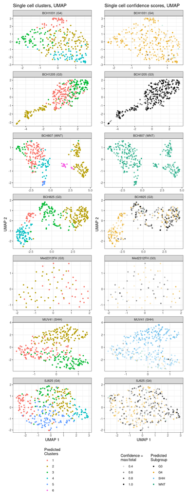

```r
cluster_confidence_plot_object <- umap_labels_combined_df |>
  ggplot2::ggplot(ggplot2::aes(x = UMAP_1,
                               y = UMAP_2,
                               color = max_subgroup,
                               alpha = confidence)) +
  ggplot2::geom_point(shape = 16) +
  ggplot2::scale_color_manual(values = okabe_ito_colors) +
  ggplot2::scale_alpha_continuous(range = c(0, 1)) +
  ggplot2::facet_wrap(~ sample_with_subgroup, ncol = 1,
                      scales = "free") +
  ggplot2::labs(title = "Single cell confidence scores, UMAP",
                x = "UMAP 1",
                y = "UMAP 2",
                alpha = "Confidence =\nmax/total",
                color = "Predicted\nSubgroup") +
  ggplot2::theme_bw() +
  ggplot2::theme(legend.position = "bottom",
                 legend.direction = "vertical")

cluster_plot_object <- umap_labels_combined_df |>
  ggplot2::ggplot(ggplot2::aes(x = UMAP_1,
                               y = UMAP_2,
                               color = cluster)) +
  ggplot2::geom_point(shape = 16) +
  ggplot2::facet_wrap(~ sample_with_subgroup, ncol = 1,
                      scales = "free") +
  ggplot2::labs(title = "Single cell clusters, UMAP",
                x = "UMAP 1",
                y = "UMAP 2",
                color = "Predicted\nClusters") +
  ggplot2::theme_bw() +
  ggplot2::theme(legend.position = "bottom",
                 legend.direction = "vertical")

combined_umap_plot_object <- patchwork::wrap_plots(cluster_plot_object,
                                                   cluster_confidence_plot_object,
                                                   nrow = 1)

ggplot2::ggsave(filename = combined_umap_plot_filepath,
                plot = combined_umap_plot_object,
                height = 20,
                width = 7.5)

combined_umap_plot_object
```

### Plot relative confidence of individual cell predictions

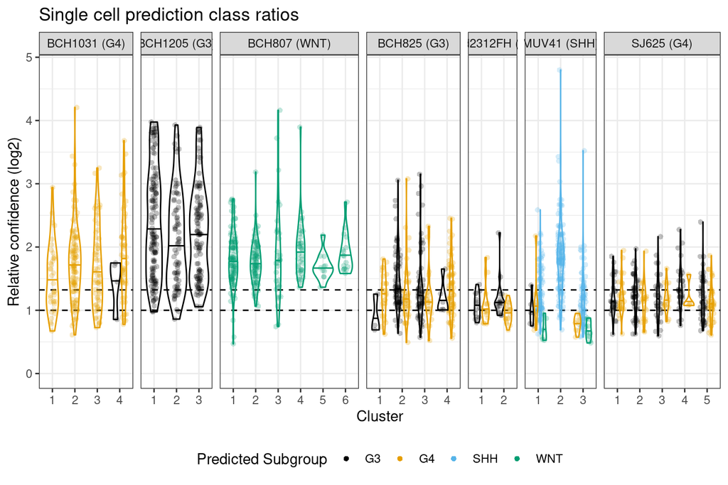

```r
# filter out subgroup predictions if that class makes up less than 5% of a cluster
# or, keep subgroups comprising at least 5% of a cluster
keep_subgroups_df <- umap_labels_combined_df |>
  dplyr::count(sample_with_subgroup, cluster) |>
  dplyr::rename(cluster_size = n) |>
  dplyr::left_join(umap_labels_combined_df |>
                     dplyr::count(sample_with_subgroup, cluster, max_subgroup),
                   by = c("sample_with_subgroup", "cluster"),
                   multiple = "all") |>
  dplyr::mutate(subgroup_cluster_pct = 100*n/cluster_size) |>
  dplyr::filter(subgroup_cluster_pct >= 5) |>
  dplyr::select(sample_with_subgroup, cluster, max_subgroup) |>
  unique()

# Use cells from subgroups comprising at least 5% of a cluster to plot relative
# confidence levels of each prediction. The relative confidence level is the
# dominant subgroup score divided by the sum of the remaining subgroup scores.
set.seed(1) # reproducibility
relative_confidence_plot_object <- keep_subgroups_df |>
  dplyr::left_join(umap_labels_combined_df,
                   by = c("sample_with_subgroup", "cluster", "max_subgroup"),
                   multiple = "all") |>
  dplyr::filter(relative_confidence < Inf) |>
  ggplot2::ggplot(ggplot2::aes(x = cluster,
                               y = log2(relative_confidence + 1), # log2 scale + 1
                               color = max_subgroup)) +
  # 1 and 1.5 relative confidence levels correspond to 50% and 60% of a cell's
  # prediction score going to the dominant subgroup
  ggplot2::geom_hline(yintercept = c(log2(1+1), log2(1.5+1)),
                      lty = 2) +
  ggplot2::geom_point(shape = 16,
                      position = ggplot2::position_jitterdodge(jitter.height = 0,
                                                               jitter.width = 0.25,
                                                               dodge.width = .75),
                      alpha = 0.25) +
  ggplot2::geom_violin(fill = NA,
                       draw_quantiles = 0.5,
                       position = ggplot2::position_dodge(width = 0.75),
                       show.legend = FALSE) +
  ggplot2::facet_grid(cols = ggplot2::vars(sample_with_subgroup),
                      space = "free_x",
                      scales = "free_x") +
  ggplot2::scale_color_manual(values = okabe_ito_colors) +
  ggplot2::scale_y_continuous(limits = c(0, NA)) +
  ggplot2::labs(title = "Single cell prediction class ratios",
                x = "Cluster",
                y = "Relative confidence (log2)",
                color = "Predicted Subgroup") +
  ggplot2::theme_bw() +
  ggplot2::theme(legend.position = "bottom") +
  ggplot2::guides(colour = ggplot2::guide_legend(override.aes = list(alpha = 1)))

ggplot2::ggsave(filename = relative_confidence_plot_filepath,
                plot = relative_confidence_plot_object,
                width = 7.5, height = 5)

relative_confidence_plot_object
```

- Takeaway: Cell subgroup predictions are more confident when subgroup predictions are consistent across entire sample.
- The relative confidence levels of each cell’s prediction show that predictions in samples with one dominant subgroup are more confident than in samples with mixed subgroup predictions (BCH825, Med2312FH, SJ625).
- While some cells from mixed subgroup samples show high confidence as G3 or G4, most show that cells receive signals from both G3 and G4 rules, meaning they have an intermediate phenotype, rather than being a mixture of true G3 and true G4 cells.
- Sample MUV41 has G3, G4, and WNT cells predicted in clusters 1 and 3, but they are all low confidence in comparison to the SHH cells in the major cluster (2).